# Qualidade do Vinho

INFNET MIT Big Data - Bloco A - Trabalho de R

Fernando Peres

6/9/2017

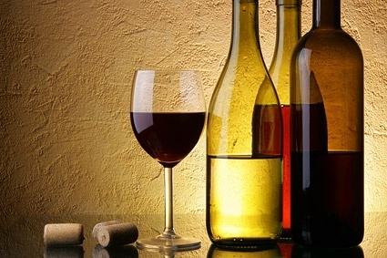

# Introdução

## Sobre o estudo - *WINE QUALITY*

Há dois datasets neste estudo, um sobre vinho tinto e outro sobre vinho branco.

## Cojunto de Dados:

1. Vinho Tinto (*winequality-red.csv*) com w = 1599 observações.
2. Vinho Branco (*winequality-white.csv*) com w = 4898 observações.

**TOTAL DE OBSERVAÇÕES W = 6497 observações.**

Os dois conjuntos de dados estão relacionados a variantes de vinhos tinto e vinhos brancos portugueses. Devido a problemas de privacidade e outras questões, apenas as variáveis fisicoquímicas (entradas) e sensoriais (de saída) estão disponíveis. Neste sentido, não há dados sobre os tipos de uvas, marca de vinho, preço de venda de vinho, etc.)

## Atributos

Ambos os data sets possuem os mesmos **12 atributos**:

1. fixed.acidity = Acidez fixa
2. volatile.acidity = Acidez volátil
3. citric.acid = Ácido cítrico
4. residual.sugar = Açucar residual
5. chlorides = Cloretos
6. free.sulfur.dioxide = Livre de dióxido de enxofre
7. total.sulfur.dioxide = Total de dióxido de enxofre
8. density = Densidade
9. pH = pH
10. sulphates = Sulfatos
11. alcohol = Teor alcólico
12. quality = Qualidade

Esses conjuntos de dados podem ser vistos para atividades de classificação ou regressão. As clases são encomendadas e não equilibradas (por exemplo, existem mais vinhos normais do que excelentes ou pobres). Os algoritmos de detecção de Outlier podem ser usados para detectar alguns vinhos excelentes ou pobres. Além disso, não temos certeza se todas as variáveis de entrada são relevantes. Portanto, pode ser interessante testar métodos de seleção de recursos.

## Fonte dos dados

Os dados foram baixados do site: [UCI - Machine Learning Repository](https://archive.ics.uci.edu/ml/datasets/wine+quality)

## Para mais informações

Cortez et al., 2009 [Modeling wine preferences by data mining from physicochemical properties](http://www.sciencedirect.com/science/article/pii/S0167923609001377?via%3Dihub)

# 6. Análise multivariada (Gosto / $taste)

## Setup: Definição de “caminhos”

Difinição do caminho padrão, para utilizar este código no seu computador, mude a string *wine.path* para a pasta onde você descarregou os arquivos do projeto. O local onde estarão os dados e demais códigos do *R* se ajustarão automaticamente.

```r
# ******************************************************************************
# #### SETUP ####
# ******************************************************************************
## work directory path ##
wine.path = "/Users/fernandoperes/dev/r/r-wine/" # to be reused as needed
setwd(wine.path)
## Sources
source(file =  paste(wine.path, "wines-0-utils.R", sep = ""))
## Libraries
## Libraries
library(party)
library(rpart)
library(rpart.plot)
library(ipred)
library(randomForest)
library(C50)

getwd()
```

```
## [1] "/Users/fernandoperes/dev/r/r-wine"
```

```r
# ******************************************************************************
# #### Load prepared data files ####
# ******************************************************************************
load(file="all-wine.Rda") # load(file="red-wine.Rda") # load(file="white-wine.Rda")
```

## Introdução

A seguir serão realizadas análises utilizando diversos algoritmos e para comparar os seus resultados.

### Formula que será usada pelos algoritmos:

#### Variável dependente: gosto / *$taste*

#### Variáveis independentes: todas exceto: $color, $quality e auxiliares de cores.

```r
# ******************************************************************************
# #### Configure and run ctree algorithm ####
# ******************************************************************************
model.config <- taste ~ fixed.acidity +
  volatile.acidity +
  citric.acid +
  residual.sugar +
  chlorides +
  free.sulfur.dioxide +
  total.sulfur.dioxide +
  density +
  pH +
  sulphates +
  alcohol

model.config
```

```
## taste ~ fixed.acidity + volatile.acidity + citric.acid + residual.sugar +
##     chlorides + free.sulfur.dioxide + total.sulfur.dioxide +
##     density + pH + sulphates + alcohol
```

## Definição dos conjuntos de treino e de teste

- 80% para o conjunto de *Treino*
- 20% para o conjunto de *Teste*

```r
ind <- sample(2, nrow(all.wine), replace = TRUE, prob = c(0.8, 0.2))
trainData <- all.wine[ind == 1,]
testData <- all.wine[ind == 2,]

nrow(trainData)
```

```
## [1] 5176
```

```r
nrow(testData)
```

```
## [1] 1321
```

## 1. CTREE

Roda o algoritmo conforme a configuração Apresenta a matrix de confusão

```r
#*******************************************************************************
# 1. train: CTREE
#*******************************************************************************
wine.ctree <- ctree(model.config, data = trainData)

# confusion matrix (test set)
wine.ctree.Predict <- predict(wine.ctree, newdata = testData)
(wine.ctree.test.table <- table(wine.ctree.Predict, testData$taste))
```

```
##
## wine.ctree.Predict bom regular ruim
##            bom     113     102   21
##            regular 113     333  139
##            ruim     14     172  314
```

### Resultado Acerto X Erros

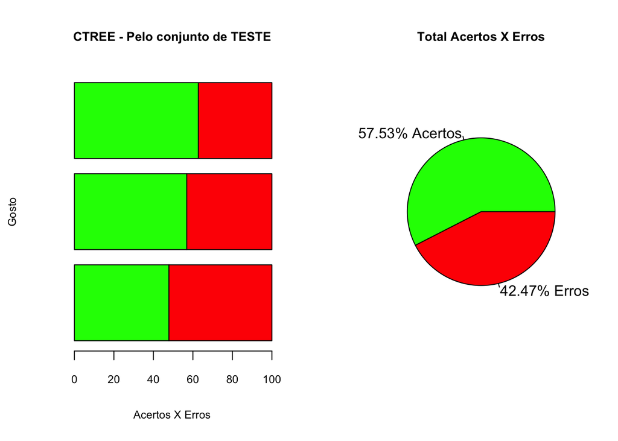

```r
# plot confusion matrix results based on test set
par.customized <- par(mfrow = c(1, 2))
plot.model.summary.by.taste(t = wine.ctree.test.table, title = "CTREE - Pelo conjunto de TESTE")
```

## 2. CART

Roda o algoritmo conforme a configuração Apresenta a matrix de confusão

```r
#*******************************************************************************
# 2. train: CART - CLASSIFICATION AND REGRESSION TREES
# Faz a divisão da árvore com base nos valores que minimizam uma funçãoo de custo,
# como soma dos mínimos quadrados.
#*******************************************************************************

# run algorithm
wine.CART <- rpart(model.config, data = trainData)

# confusion matrix (test set)
CART.predictions <- predict(wine.CART, testData, type = "class")
(wine.CART.table  <- table(CART.predictions, testData$taste))
```

```
##
## CART.predictions bom regular ruim
##          bom      62      52    9
##          regular 165     388  186
##          ruim     13     167  279
```

### Resultado Acerto X Erros

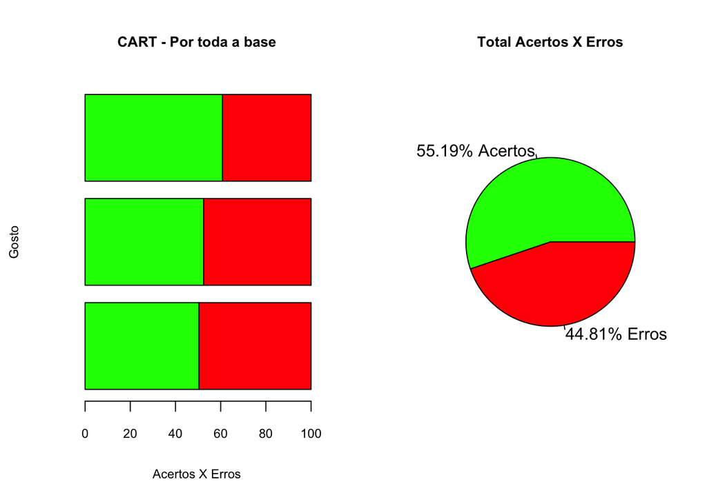

```r
# plot confusion matrix results based on test set
par.customized <- par(mfrow = c(1, 2))
plot.model.summary.by.taste(t = wine.CART.table, title = "CART - Por toda a base")
```

3. Bagging CART Roda o algoritmo conforme a configuração Apresenta a matrix de confusão

```r
#*******************************************************************************
# 3. train: BAGGING CART (Training set x Test Set)
# Faz a divisão da árvore com base nos valores que minimizam uma funçãoo de custo,
# como soma dos mínimos quadrados.
#*******************************************************************************
wine.bagginCart <- bagging(model.config, data = trainData)

# confusion matrix (test set)
bagginCart.predictions <- predict(wine.bagginCart , testData, type = "class")
(wine.bagginCart.table  <- table(bagginCart.predictions, testData$taste))
```

```
##
## bagginCart.predictions bom regular ruim
##                bom     162      65    7
##                regular  72     418  110
##                ruim      6     124  357
```

### Resultado Acerto X Erros

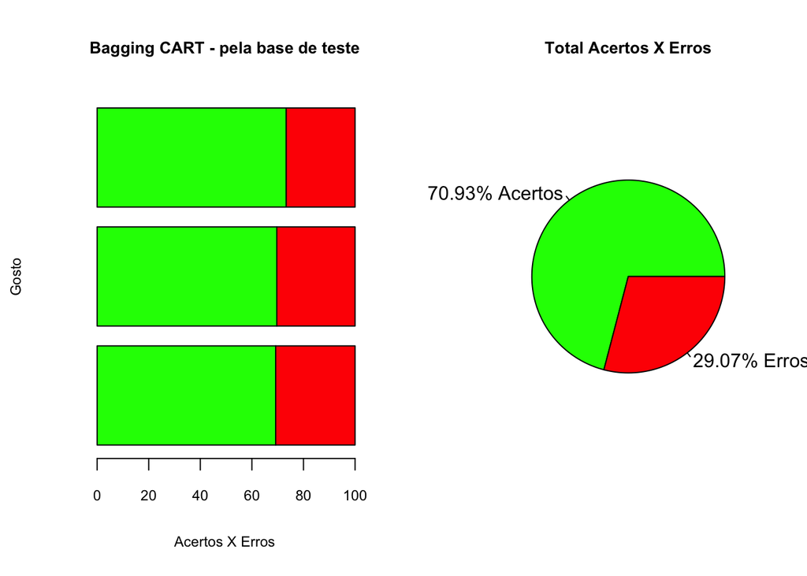

```r
# plot confusion matrix results based on test set
par.customized <- par(mfrow = c(1, 2))
plot.model.summary.by.taste(t = wine.bagginCart.table, title = "Bagging CART - pela base de teste")
```

## 4. C5.0

Roda o algoritmo conforme a configuração Apresenta a matrix de confusão

```r
#*******************************************************************************
# 4. train: C5.0 (Training set x Test Set)
# Faz a divisão da árvore com base nos valores que minimizam uma funçãoo de custo,
# como soma dos mínimos quadrados.
#*******************************************************************************
wine.C5.0 <- C5.0(model.config, data = trainData)

# confusion matrix (test set)
C5.0.predictions <- predict(wine.C5.0 , testData, type = "class")
wine.C5.0.table  <- table(C5.0.predictions, testData$taste)

# confusion matrix
wine.C5.0.table
```

```
##
## C5.0.predictions bom regular ruim
##          bom     143     109   24
##          regular  83     366  133
##          ruim     14     132  317
```

### Resultado Acerto X Erros

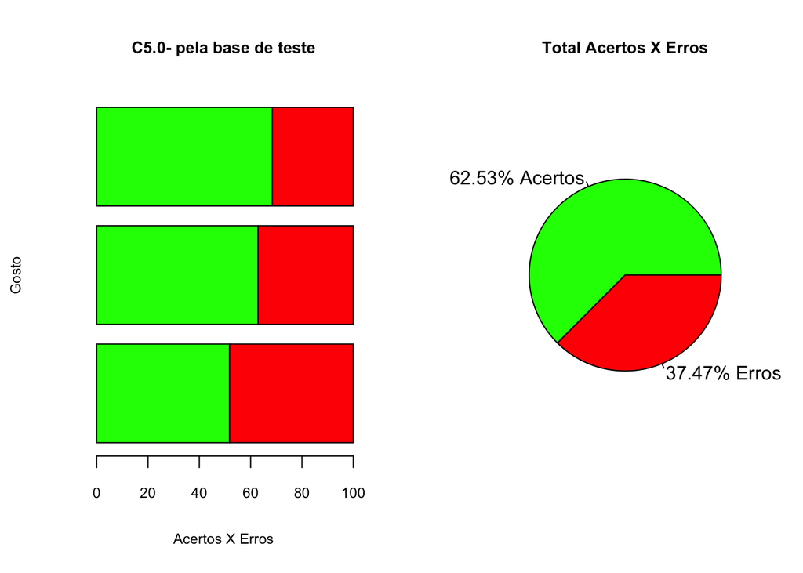

```r
# plot confusion matrix results based on test set
par.customized <- par(mfrow = c(1, 2))
plot.model.summary.by.taste(t = wine.C5.0.table, title = "C5.0- pela base de teste")
```

## 5. Random forest

Roda o algoritmo conforme a configuração Apresenta a matrix de confusão

```r
#*******************************************************************************
# 5. train: Random forrest
# Faz a divisão da árvore com base nos valores que minimizam uma funçãoo de custo,
# como soma dos mínimos quadrados.
#*******************************************************************************
wine.RF <- randomForest(model.config, data = trainData)

# confusion matrix (test set)
RF.predictions <- predict(wine.RF , testData, type = "class")
wine.RF.table  <- table(RF.predictions, testData$taste)

# confusion matrix
wine.RF.table
```

```
##
## RF.predictions bom regular ruim
##        bom     154      45    7
##        regular  82     447  105
##        ruim      4     115  362
```

### Resultado Acerto X Erros

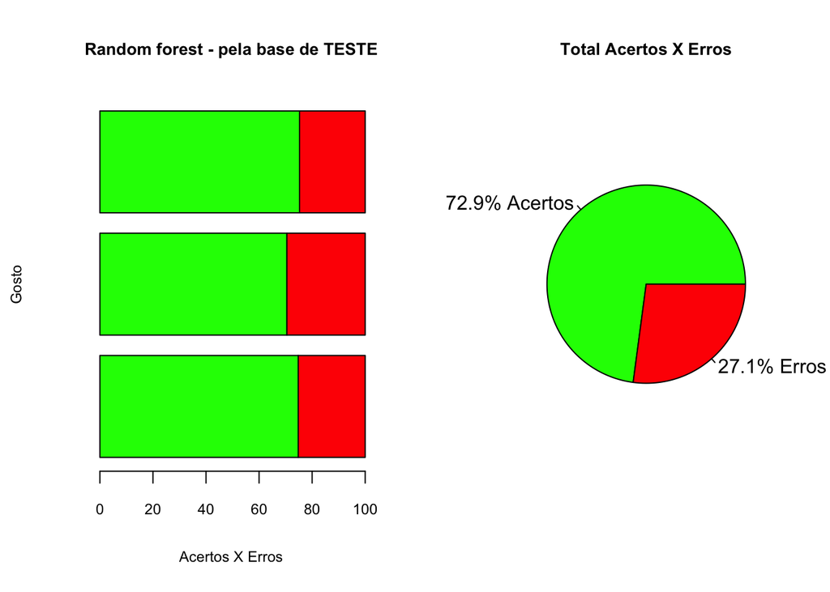

```r
# plot confusion matrix results based on test set
par.customized <- par(mfrow = c(1, 2))
plot.model.summary.by.taste(t = wine.RF.table, title = "Random forest - pela base de TESTE")
```

## Conclusão:

O melhor modelo para classificar esta base foi o **Random Forest**, seguido de perto pelo **Bagging CART**.

**Esforços futuros**

- Remover outliers e testar novamente
- Testar com outros algoritmos
- Verificar formas de aperfeiçoar os algoritmos que trouxeram melhores resultados
- fazer calculos de ganho de informação e ranquear os atributos
- Etc.